# Лабораторная работа № 1

Подготовка стенда и модель экспоненциального роста

Нечаева Кира Андреевна

knechaeva.git@gmail.com

Российский университет дружбы народов

2026-10-07

## Цель и задачи

**Цель:** подготовить рабочее пространство для лабораторных работ по имитационному моделированию и освоить инструменты воспроизводимых вычислительных исследований в Julia.

**Задачи:**

- настроить структуру курса и Git Flow;
- создать проект DrWatson;
- реализовать модель экспоненциального роста;
- провести параметрическое исследование;
- сформировать Literate, Quarto и Jupyter Notebook;
- проверить воспроизводимость вычислений.

## Рабочее пространство

В ходе подготовки были созданы:

- репозиторий курса;
- стандартная структура лабораторных работ;
- ветки `master` и `develop`;
- релиз `v1.0.0`;
- удалённые репозитории GitVerse и GitHub.

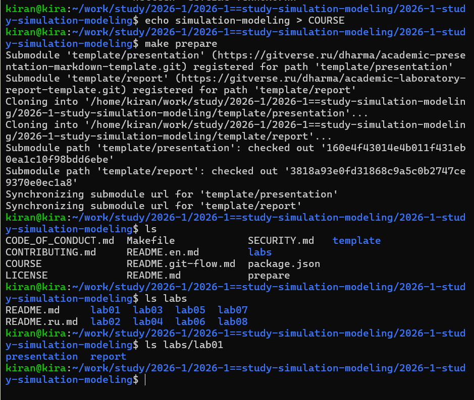

## Проект DrWatson

Для лабораторной работы создан отдельный Julia-проект.

Использованы библиотеки:

- `DifferentialEquations`;
- `Plots`;
- `DataFrames`;
- `JLD2`;
- `Literate`;
- `IJulia`;
- `BenchmarkTools`;
- `Quarto`.

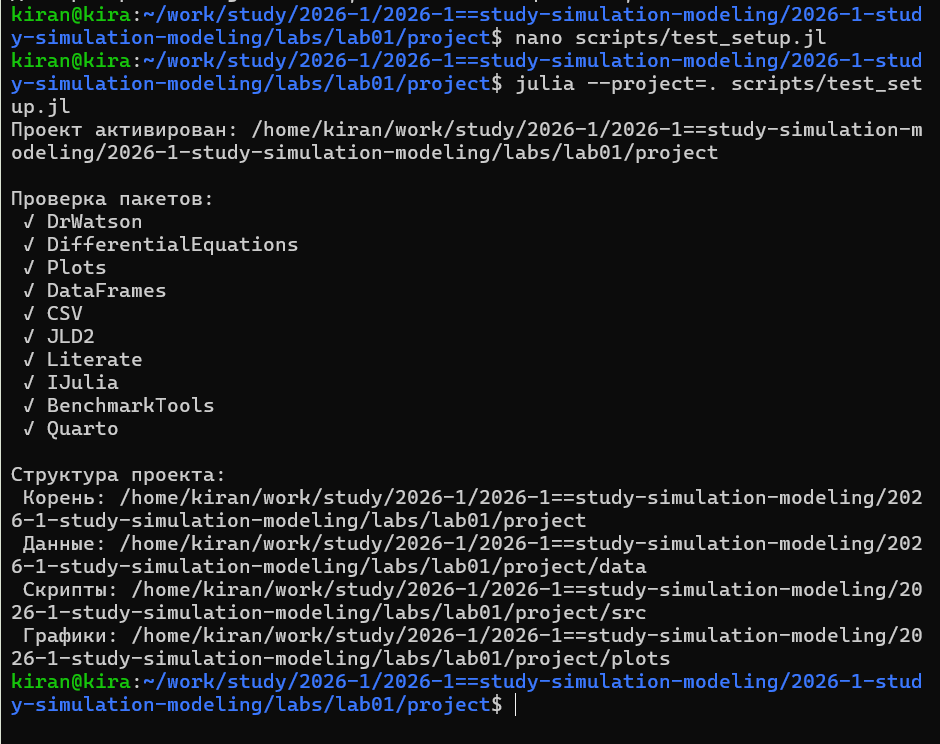

## Модель экспоненциального роста

Рассматривается модель

$$\frac{du}{dt}=\alpha u.$$

Базовые параметры:

$$u_0=1,
\qquad
\alpha=0.3,$$

$$t\in[0,10].$$

При положительном $\alpha$ величина возрастает экспоненциально.

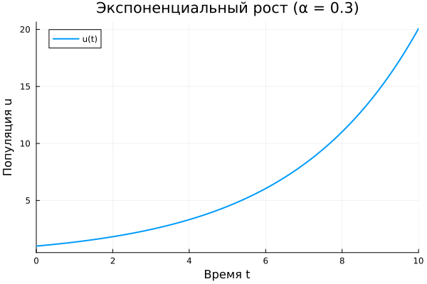

## Литературное программирование

Один исходный Julia-файл используется для автоматического создания:

- чистого Julia-кода;
- документа Quarto;
- Jupyter Notebook.

Так все представления программы формируются из одного исходника.

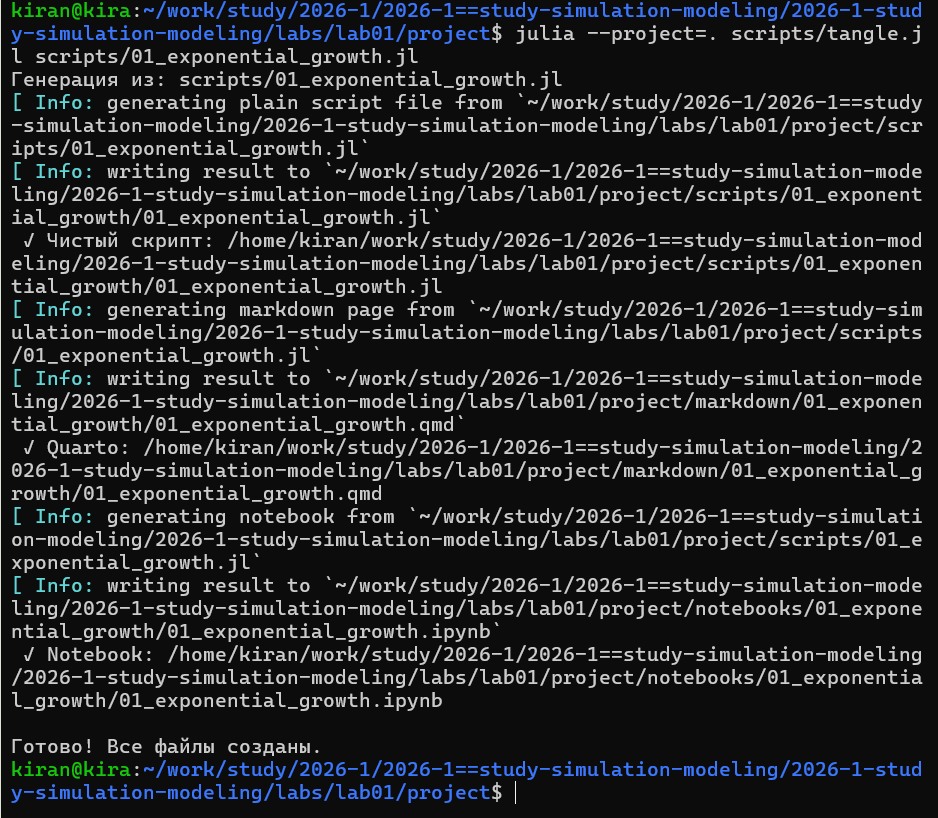

## Проверка воспроизводимости

Сгенерированный Jupyter Notebook был выполнен с использованием ядра Julia.

Это позволяет проверить, что вычисления можно повторно выполнить из автоматически созданного notebook.

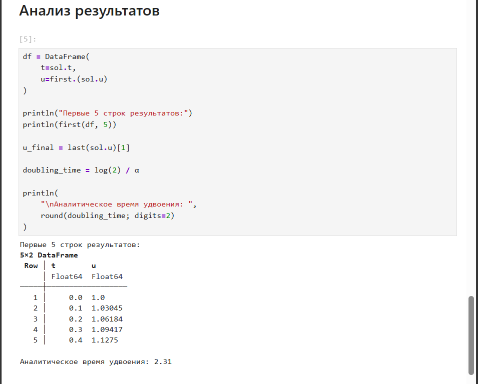

## Параметрическое исследование

Исследованы значения

$$\alpha =
0.1,\;
0.3,\;
0.5,\;
0.8,\;
1.0.$$

При увеличении $\alpha$ рост происходит значительно быстрее.

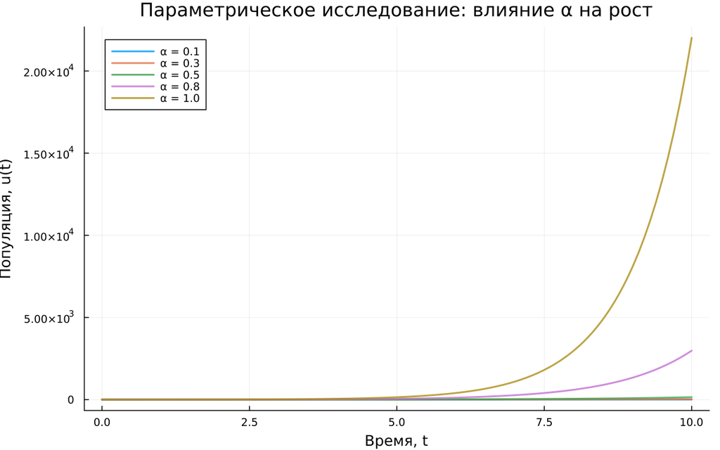

## Влияние параметра $\alpha$

С увеличением коэффициента роста $\alpha$ время удвоения уменьшается.

Для исследованных значений параметра численные результаты совпадают с теоретической зависимостью

$$t_2=\frac{\ln 2}{\alpha}.$$

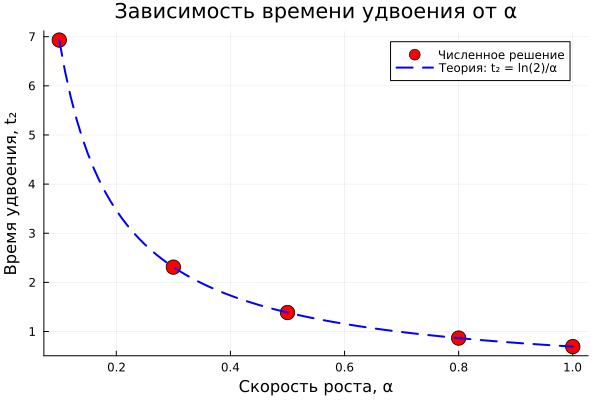

## Результаты параметрического исследования

Для всех пяти значений $\alpha$ автоматически выполнены вычисления и сохранены результаты.

Получены:

- сводная таблица;
- сравнительные траектории;
- время удвоения;
- результаты бенчмаркинга.

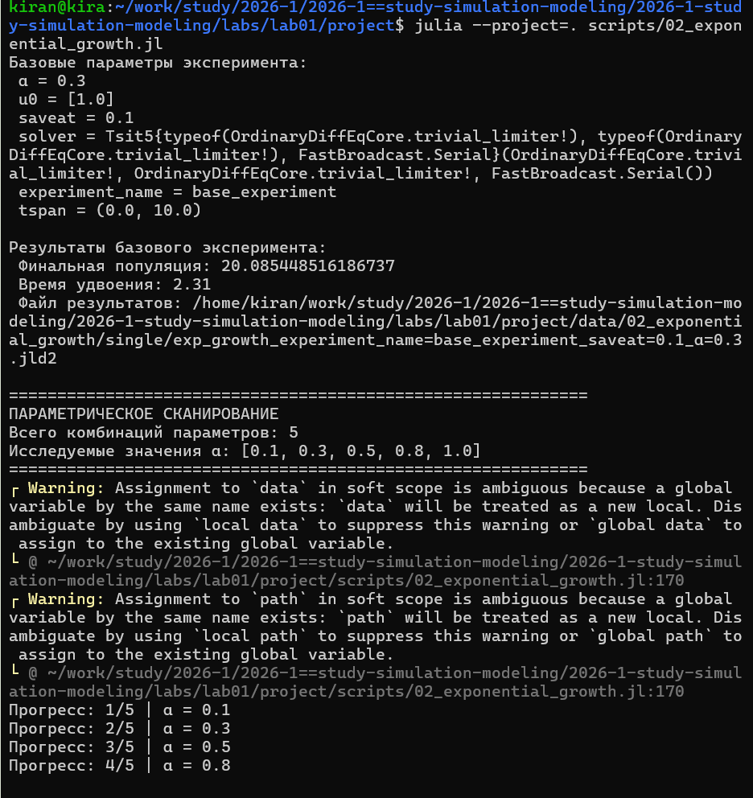

## Бенчмаркинг

Для каждого значения $\alpha$ измерялось время численного решения.

Бенчмаркинг позволяет оценить вычислительные затраты при выполнении серии экспериментов.

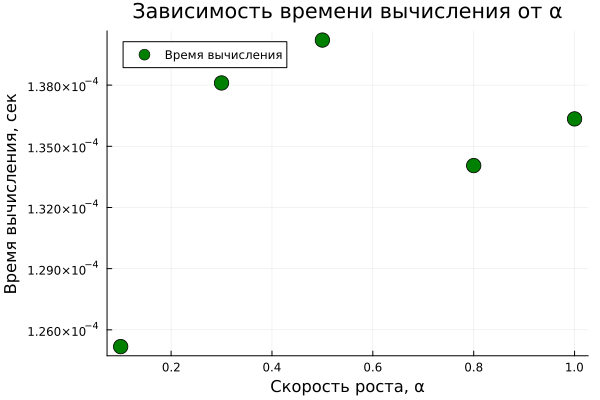

## Результаты разработки

Для обеих версий программы получены:

- исполняемый Julia-код;
- Quarto-документация;
- Jupyter Notebook;
- сохранённые данные;
- графики результатов.

Параметрический notebook также успешно выполнен.

[figure not shown]

## Итог

Для лабораторной работы подготовлено полное воспроизводимое вычислительное окружение.

- создано рабочее пространство курса;
- настроен и проверен проект DrWatson;
- реализована модель экспоненциального роста;
- выполнено исследование для пяти значений $\alpha$;
- увеличение $\alpha$ ускоряет рост и уменьшает время удвоения;
- код преобразован в Literate, Quarto и Jupyter Notebook;
- результаты сохранены в GitVerse и GitHub.

**Все этапы лабораторной работы выполнены программно и воспроизводимы.**